# HW4

Eda Kocakarin - IE360 - Fall 2020

1/24/2021

# Stationarity of Turkish Electricity Consumption Data

## Introduction

Electricity consumption is affected by many different factors. Temperature, seasonal changes, special days, holidays, days of the week and months are the main factors affecting electricity consumption. Data that vary according to more than one criteria and are significantly correlated with these are called non-stationary data. In addition, data free of trends, seasonality and variables that affect the data are called stationary.

## Data Manipulation & Visual Analysis

Firstly, downloaded electricity consumption data from EPIAS website shows hourly consumption. In order to study on daily data, I take the the mean of electricity consumption for each day. I summarize the data with respect to date information.

Below, you can see the form of the beginning data.

```
##          Date dailyConsumption
## 1: 2017-01-01         27099.66
## 2: 2017-01-02         33141.88
## 3: 2017-01-03         34769.59
## 4: 2017-01-04         35250.70
## 5: 2017-01-05         35109.35
## 6: 2017-01-06         33866.49
```

Plotting the daily consumption data is important to see pattern of the dataset. Above, you can see the graph of the Daily Mean Electricity Consumption in Turkey.

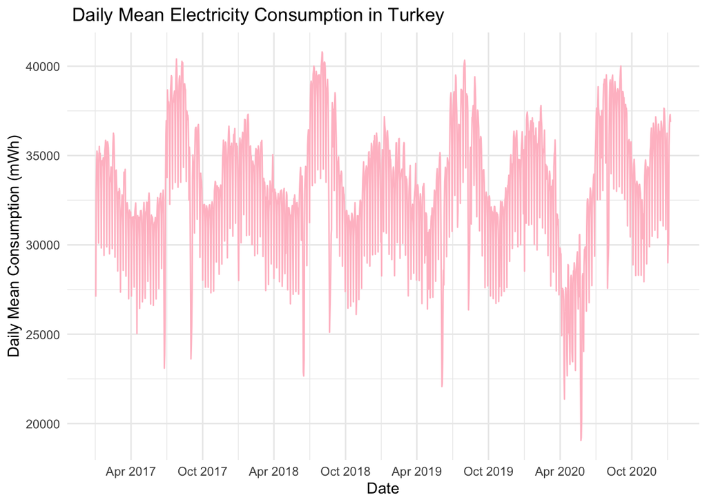

The range of our daily consumption data is from January 1, 2017 to January 8, 2021. There is an obvious seasonality when we examine the line graph. It can be said that electricity consumption changes depending on the seasonal changes. In addition, the corona virus situation, which has occurred since March 2020, has negatively affected electricity consumption. In order to get stationary data, the data will be cleared from seasonality and the time series will be decomposed to obtain a fixed data.

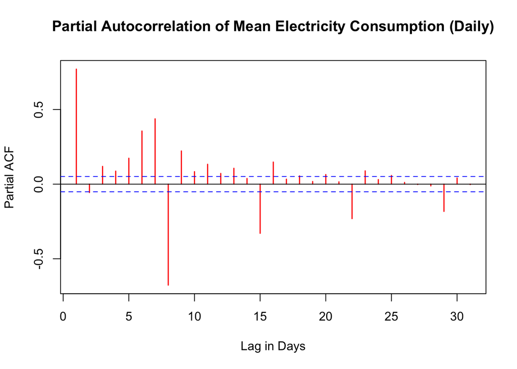

Besides, Partial autocorrelation function proves that there is a weekly seasonality. To make data stationary, we must first eliminate the effects of the days of week on electricity consumption. For this reason, a new column is added, which shows the day’s effects, then this effect is eliminated from the daily consumption. Besides, instead of effects of days, using the mean of days effects is logical. Therefore, days of week meanly effect is added to daily consumption. As a result, our daily consumption is free from weekly seasonality now. In this way, the effect of the days of the week on electricity consumption is eliminated.

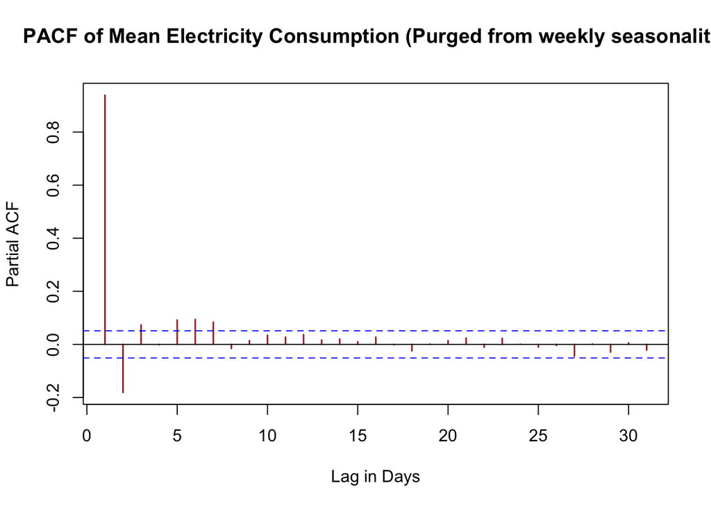

Above, you can see the PACF of the data purged from weekly seasonality. Lag 1 is still high, therefore the data can be shifted for 1 day and the daily difference of the data can be used. Before performing the necessary operations, we can apply KPSS test to check whether the data is stationary or not.

```
##
## #######################
## # KPSS Unit Root Test #
## #######################
##
## Test is of type: mu with 7 lags.
##
## Value of test-statistic is: 0.145
##
## Critical value for a significance level of:
##                 10pct  5pct 2.5pct  1pct
## critical values 0.347 0.463  0.574 0.739
```

Above, you can see the adjusted daily consumption, that is shown stationary.

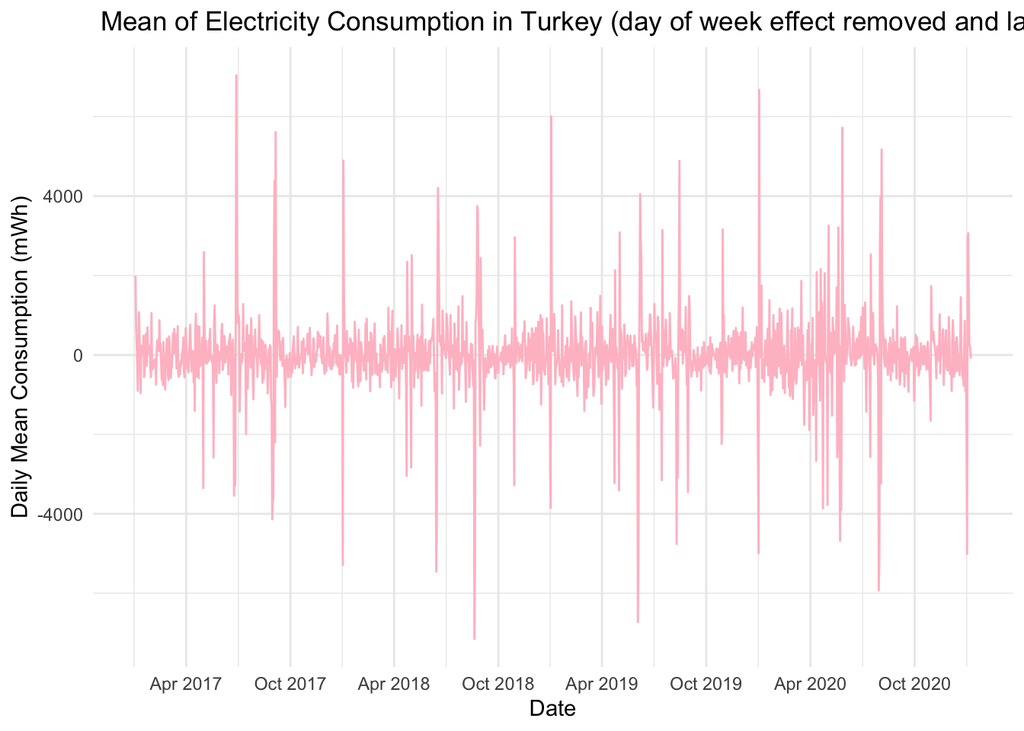

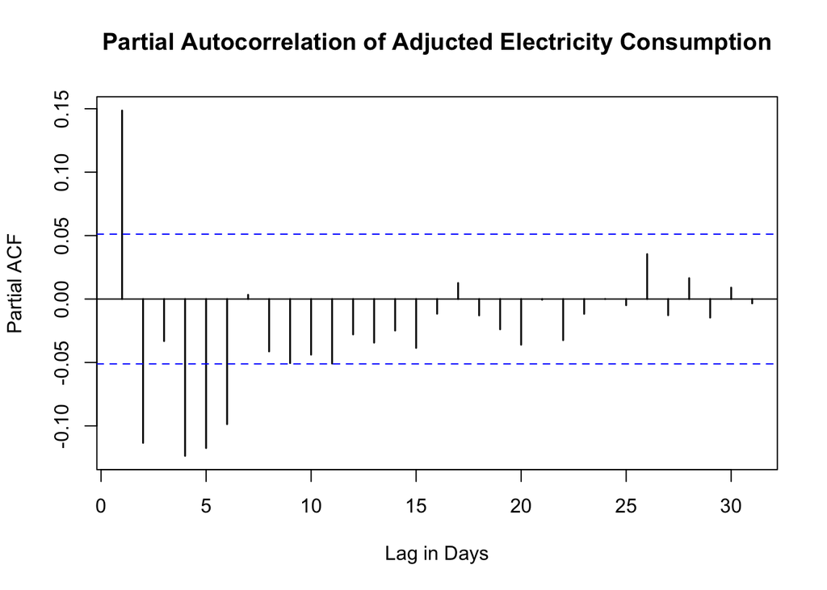

```
##
## #######################
## # KPSS Unit Root Test #
## #######################
##
## Test is of type: mu with 7 lags.
##
## Value of test-statistic is: 0.0087
##
## Critical value for a significance level of:
##                 10pct  5pct 2.5pct  1pct
## critical values 0.347 0.463  0.574 0.739
```

According to the KPSS Unit Root Test results, our test-statistic value 0.0087 is less than the critical values. Therefore, we can continue with the time series decomposition.

## Time Series Decomposition

Firstly, we create the time series object to utilize the ts function, decompose. In order to decrease monthly effect, we construct ts object with frequency 30.

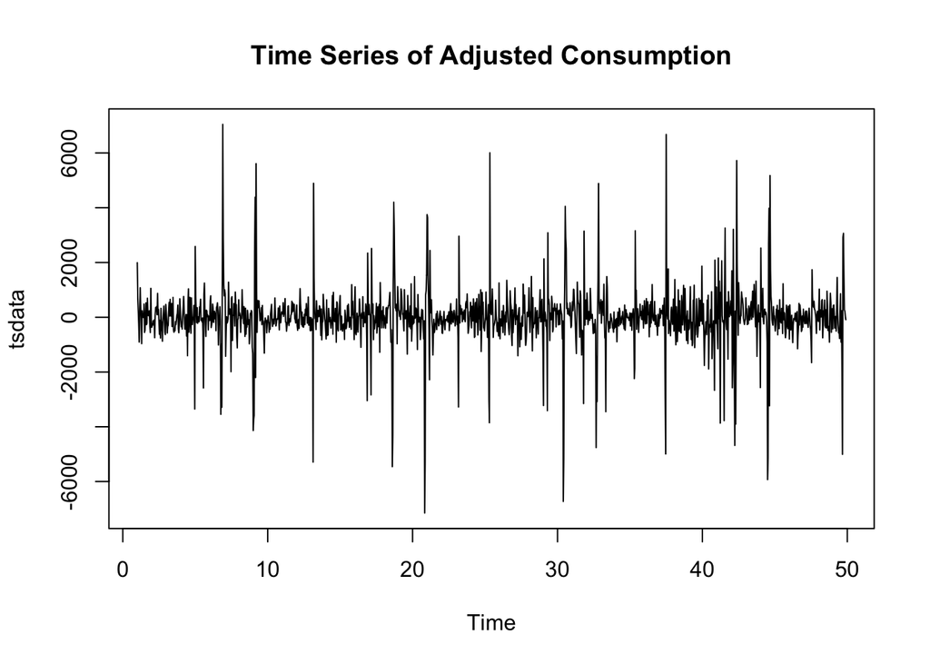

Above, you can see the ts plot of adjusted consumption. When we examine the plot, we can say that variance does not increases over time. Therefore, we prefer to use additive decomposition instead of multiplicative decomposition method.

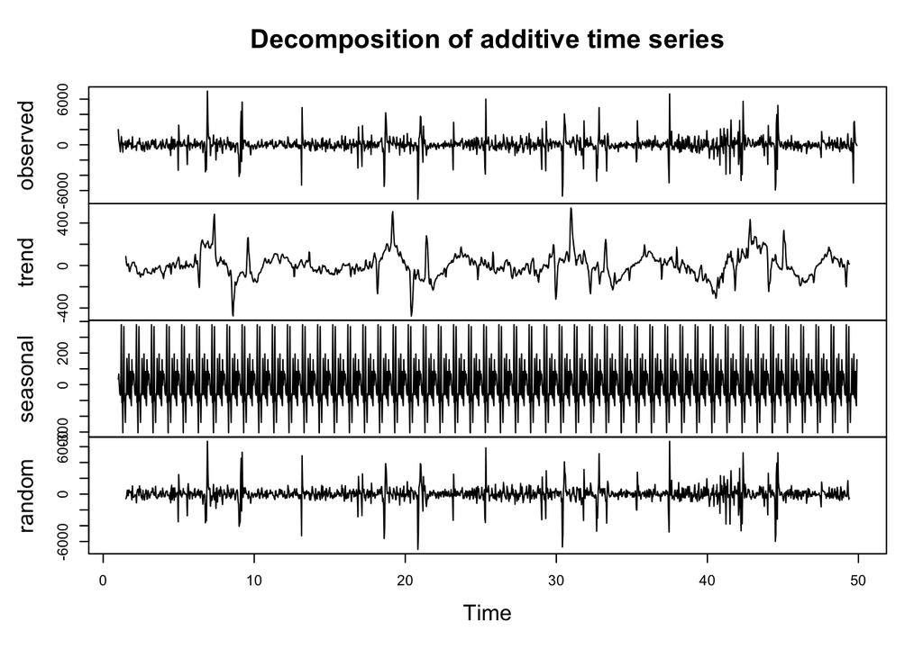

Above, you can see additive decomposition of adjusted consumption. By looking the random part, we can say there are still outliers that are caused by special days such as holidays and public days. However, since our adjusted data is stationary enough, it will be enough to clear our ts object from seasonality and trend.

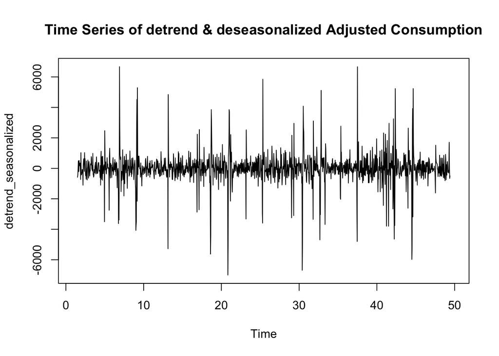

Above you can see the detrend and deseasonalized adjusted consumption.

## Stationarity & ACF/PACF

Let’s look at the kpss test result to make sure that the stationarity of data we had from the ts decomposition.

```
##
## #######################
## # KPSS Unit Root Test #
## #######################
##
## Test is of type: mu with 7 lags.
##
## Value of test-statistic is: 0.0025
##
## Critical value for a significance level of:
##                 10pct  5pct 2.5pct  1pct
## critical values 0.347 0.463  0.574 0.739
```

According to the KPSS Unit Root Test results, our test-statistic value 0.0025 is less than our last test results 0.0087 and still smaller than the critical values 0.347.

Finally, let’s take a look at our ts object, which we will put in the arima model, in detail and then set up our model.

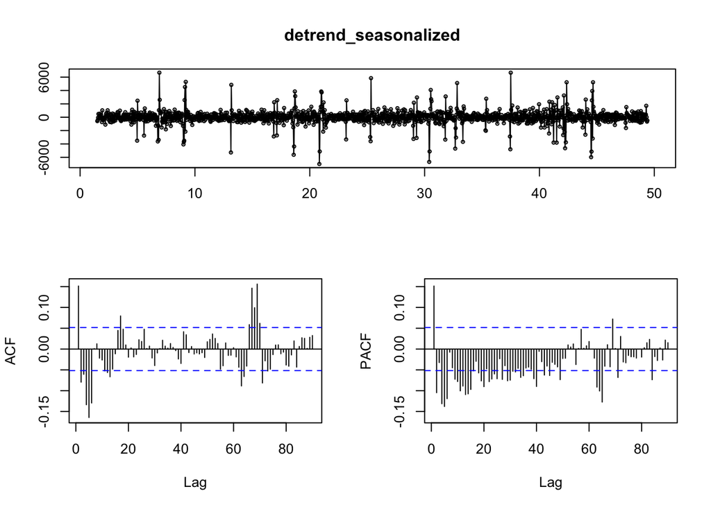

Since our ACF / PACF graphics and our detrend & deseasonalized plot are suitable for stationarity, we can move on to the model selection part with arima.

## Arima Model Selection

To begin with, I prefer to use auto.arima to find the best fit.

```
##
##  Fitting models using approximations to speed things up...
##
##  ARIMA(2,0,2)            with non-zero mean : Inf
##  ARIMA(0,0,0)            with non-zero mean : 24030.05
##  ARIMA(1,0,0)            with non-zero mean : 23999.36
##  ARIMA(0,0,1)            with non-zero mean : 23991.67
##  ARIMA(0,0,0)            with zero mean     : 24028.04
##  ARIMA(1,0,1)            with non-zero mean : 23988.15
##  ARIMA(2,0,1)            with non-zero mean : Inf
##  ARIMA(1,0,2)            with non-zero mean : Inf
##  ARIMA(0,0,2)            with non-zero mean : 23985.19
##  ARIMA(0,0,3)            with non-zero mean : 23981.53
##  ARIMA(1,0,3)            with non-zero mean : Inf
##  ARIMA(0,0,4)            with non-zero mean : Inf
##  ARIMA(1,0,4)            with non-zero mean : Inf
##  ARIMA(0,0,3)            with zero mean     : 23979.52
##  ARIMA(0,0,2)            with zero mean     : 23983.18
##  ARIMA(1,0,3)            with zero mean     : Inf
##  ARIMA(0,0,4)            with zero mean     : Inf
##  ARIMA(1,0,2)            with zero mean     : Inf
##  ARIMA(1,0,4)            with zero mean     : Inf
##
##  Now re-fitting the best model(s) without approximations...
##
##  ARIMA(0,0,3)            with zero mean     : 23979.58
##
##  Best model: ARIMA(0,0,3)            with zero mean
```

According to results of auto.arima, best model is ARIMA(0,0,3). When finding the best model, Arima looks to the AIC and BIC values. Lower AIC or BIC is better for the reliable of the model. AIC estimates the relative amount of information lost by a given model and BIC looks penalty for the number of parameters.

Below, you can see the coefficients of the ARIMA(0,0,3) model and corresponding AIC and BIC values.

```
##
## Call:
## arima(x = detrend_seasonalized, order = c(0, 0, 3))
##
## Coefficients:
##          ma1      ma2      ma3  intercept
##       0.1433  -0.1296  -0.0836     0.1232
## s.e.  0.0281   0.0358   0.0355    24.7405
##
## sigma^2 estimated as 1016765:  log likelihood = -11985.78,  aic = 23981.55
```

```
## [1] 23981.55
```

```
## [1] 24007.91
```

## Forecasting with ARIMA(0,0,3) Model

First of all, we make a 14-day forecast with our arima model. Then we undo the ts decomposition moves we made to obtain stationary consumption data.

Then, we get our 14-day forecast by correcting the action we have made to reduce the effect of the days of the week.

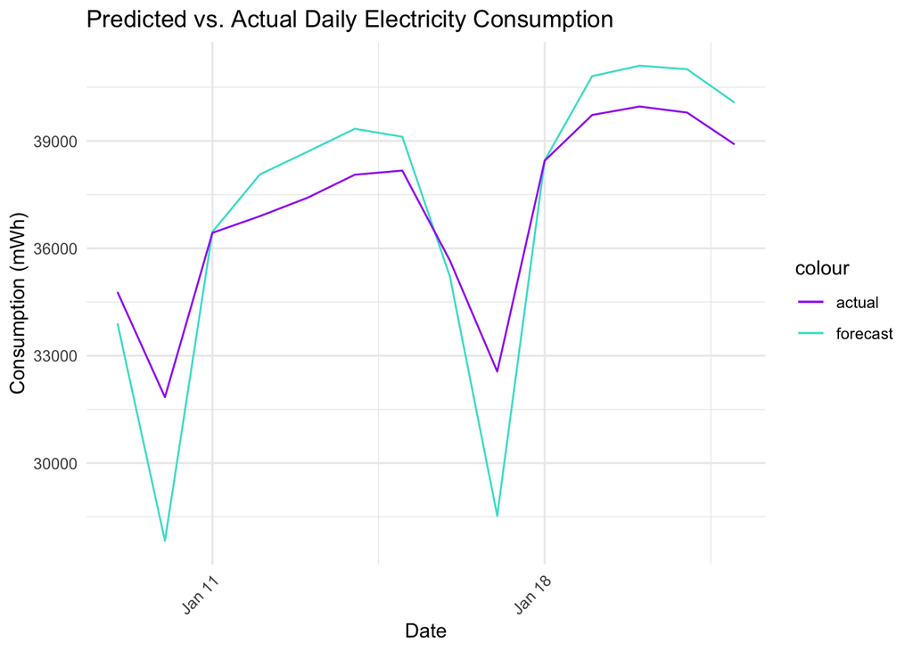

Lastly, we take the real electricity consumption value from EPIAS website. Above, you can see the actual vs predicted graph.

## Performance Measures (Back-Testing)

Testing the prediction we make as a result of the model we have set up is a feedback mechanism that shows our performance. For this reason, we compare our actual and forecasted data and look at measures such as mean, sd, error, FBias, MAPE, MAD, WMAPE.

```
##    n     mean       sd    error        FBias       MAPE      MAD    WMAPE
## 1 14 37045.79 2567.339 875.9856 8.499298e-05 0.03777586 1333.723 0.036002
```

By looking the test statistics, we can say that ARIMA(0,0,3), 3 moving average, model is applicable. Our model has lower WMAPE value, which is an indicator of model suitability.

## Conclusion

First of all, the hourly electricity consumption data we received from the EPIAS website converted into a daily data set using the mean function. Then, we started the steps of making electricity consumption stationary, which is one of the main objectives of the assignment. The effect of the days of the week on consumption was observed and eliminated. In PACF analysis, the high value in lag-1 observed, then lag 1 of consumption data was taken to eliminate daily consumption from lag1 Daily consumption is shifted and then subtracted from each other. Consequently, the adjusted consumption data obtained were converted to the time series object and the decomposition property of ts was used. Adjusted consumption composed from trend and seasonality.

Necessary investigations were made and data stationary came out according to the KPSS test result. For this reason, the most suitable arima model was searched with the auto.arima function and ARIMA(0,0,3) has found to be best model. Estimation was made using the ARIMA (0,0,3) model and then the actual vs predicted graph was observed. The goodness of our model has been tested. Some statistical values such as mean, sd, error, FBias, MAPE, MAD, WMAPE were observed and necessary comments were made.

## References

[EPIAS](https://seffaflik.epias.com.tr/transparency/tuketim/gerceklesen-tuketim/gercek-zamanli-tuketim.xhtml)

## Appendices

[Here](https://github.com/BU-IE-360/fall20-edakocakarin/blob/gh-pages/files/HW4.Rmd) is my RMD file about this assignment.